# Figures for Spatial Transcriptomics of hFTE

# Summary

The purpose of this R notebook is to create the figures for the paper:

“Spatial Transcriptomic Profiling of the Human Fallopian Tube Epithelium Reveals Region-specific Gene Expression Patterns”

This document uses a GeoMx dataset that has already undergone Quality control and normalization.

For details, see: geomx_dataset_and_normalization.Rmd

# 1.0 Setup

# 1.1 Load Packages

The following packages are needed for this document.

```r
#
# if (!require("BiocManager", quietly = TRUE))
#     install.packages("BiocManager")

# The following initializes most up to date version of Bioc
# BiocManager::install(version="3.15")
#
# BiocManager::install("NanoStringNCTools")
# BiocManager::install("GeomxTools")
# BiocManager::install("GeoMxWorkflows")

# Note:
# Needed to install package lme4, numderiv
library(NanoStringNCTools)
library(GeomxTools)
library(GeoMxWorkflows)

if(packageVersion("GeomxTools") < "2.1" &
   packageVersion("GeoMxWorkflows") >= "1.0.1"){
    stop("GeomxTools and Workflow versions do not match. Please use the same version.
    This workflow is meant to be used with most current version of packages.
    If you are using an older version of Bioconductor please reinstall GeoMxWorkflows and use vignette(GeoMxWorkflows) instead")
}

if(packageVersion("GeomxTools") > "2.1" &
   packageVersion("GeoMxWorkflows") <= "1.0.1"){
    stop("GeomxTools and Workflow versions do not match.
         Please use the same version, see install instructions above.")

    # to remove current package version
        # remove.packages("GeomxTools")
        # remove.packages("GeoMxWorkflows")
    # see install instructions above
}
```

```r
# for file names
library(here)

# read in xl files
library(readxl)


# Need for UMAP, tSNE plots
library(umap)
library(Rtsne)

# Needed for the heatmap plotting
library(ComplexHeatmap)

#Needed for volcano plotting functions

library(ggrepel)
library(ggplot2)
library(latex2exp)
library(plyr)
library(dplyr)


# Read in images and convert to ggplot object

library(magick)


# used for some color palettes
library(RColorBrewer)
library(stringi)


# For significance
library(ggpubr)


# For Stitching multiple plots together
library(patchwork)
library(cowplot)
library(grid)
```

# 1.2 Load the Dataset and all Analyses Used

```r
# make sure to use correct "here" function.

load(here::here("all_q_norm.Rdata"))

load(here::here("disc_q_norm.Rdata"))

load(here::here("valid_q_norm.Rdata"))


dim(all_q_norm)
```

```
Features  Samples
    1026      129
```

```r
dim(disc_q_norm)
```

```
Features  Samples
    1026       77
```

```r
dim(valid_q_norm)
```

```
Features  Samples
    1018       50
```

Refactor the GeoMx objectes to use simplified region names.

```r
factor_region <- function(GeoMxObj = all_q_norm){
  pData(GeoMxObj)$region <- factor(pData(GeoMxObj)$region, levels = c("Fimbria", "Infundibulum", "Ampulla", "Isthmus"))

  pData(GeoMxObj)$region <- revalue(pData(GeoMxObj)$region, c("Fimbria"="Fim", "Infundibulum"="Inf", "Ampulla" = "Amp", "Isthmus" = "Isth"))

  return(GeoMxObj)
}


all_q_norm <- all_q_norm |> factor_region()

disc_q_norm <- disc_q_norm |> factor_region()

valid_q_norm <- valid_q_norm |> factor_region()
```

Subset the “all” dataset into discovery and validation datasets.

The major difference between these datasets and the “disc_q_norm” and “valid_q_norm” is that the latter were normalizzed separately. In contrast, all_disc and all_valid were normalized together and comparisons of gene expression between the two datasets are valid.

```r
all_disc <- all_q_norm[, pData(all_q_norm)$Patient %in% c("P1", "P2", "P3")]

`%ni%` <- Negate(`%in%`)

all_valid <- all_q_norm[, pData(all_q_norm)$Patient %ni% c("P1", "P2", "P3")]
```

# 2. Figure 1

Figure 1A-F are images and are not found in this document.

Figure 1G was generated in the GeoMx Normalization document.

## 2.2 Figure 1H

### FUNCT: cil_v_sec_boxplot_points()

The following function is used to create boxplots comparing the expression of PAX8 and FOXJ1 in ciliated and secretory segments. The purpose is to validate segment separation worked correctly.

```r
cil_v_sec_boxplot_points <- function(gene = "FOXJ1", point_size = 3, dataset = all_q_norm){
    set.seed(42)
    vector <- as.vector(assayDataElement(dataset[gene, ], elt = "q_norm"))
    plot <- ggplot(pData(dataset),
      aes(x = segment,
          y = vector,
          fill = segment
          )
      )+
      geom_boxplot(outlier.shape = NA)+
      labs(title = TeX(paste0("\\textit{", gene, "}")),
           y = TeX(paste0("\\textit{", gene, "} Expression")),
           x = "Cell Type")+

      geom_jitter(size = point_size, width = 0.25, stroke = 0.3)+
      scale_fill_manual(values =c("green", "red"))+

      theme_bw()+

    stat_compare_means(
      comparisons = list(c("Ciliated", "Secretory")),
      method = "t.test",
      bracket.nudge.y = -0.5,
      size = point_size+5)+

      scale_y_continuous(expand = expansion(mult = c(0.05, 0.10)))


  return(plot)

}
```

```r
text_size <- 25

# For Discovery Dataset

FOXJ1_d <- cil_v_sec_boxplot_points(gene = "FOXJ1", dataset = disc_q_norm) + theme(text=element_text(size=text_size)) + theme(legend.position = "none")

PAX8_d <- cil_v_sec_boxplot_points(gene = "PAX8", dataset = disc_q_norm) + theme(text=element_text(size=text_size)) + theme(legend.position = "none")


# For Validation Dataset

FOXJ1_v <- cil_v_sec_boxplot_points(gene = "FOXJ1", dataset = valid_q_norm) + theme(text=element_text(size=text_size)) + theme(legend.position = "none")

PAX8_v <- cil_v_sec_boxplot_points(gene = "PAX8", dataset = valid_q_norm) + theme(text=element_text(size=text_size)) + theme(legend.position = "none")



title1 <- grid::textGrob(label = "Discovery", gp=gpar(fontsize=35))
title2 <- grid::textGrob(label = "Validation", gp=gpar(fontsize=35))

# Patchwork is used to combine plots

combine_1 =  (wrap_elements(panel = title1) / (FOXJ1_d + PAX8_d)) + plot_layout(heights = c(1.5, 10))
```

|  | t | l | b | r |
| --- | --- | --- | --- | --- |
| 1: | 1 | 1 | 1 | 1 |
| 2: | 1 | 2 | 1 | 2 |

```r
combine_2 =  (wrap_elements(panel = title2) / (FOXJ1_v + PAX8_v)) + plot_layout(heights = c(1.5, 10))
```

|  | t | l | b | r |
| --- | --- | --- | --- | --- |
| 1: | 1 | 1 | 1 | 1 |
| 2: | 1 | 2 | 1 | 2 |

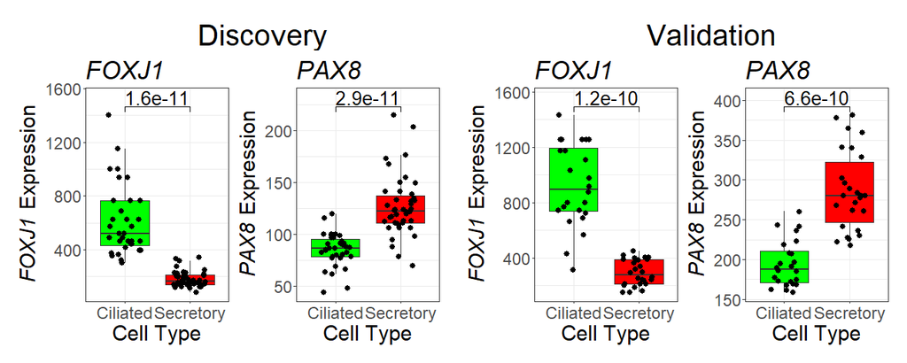

```r
wrap_elements(combine_1)|wrap_elements(combine_2)
```

# 3. Figure 2

Volcano plots for figure 2 generated separately.

# 4. Figure 3

## 4.1 Figure 3A

Figure 3A is an image generated using BioRender. It is read in below and converted to a ggplot object.

```r
# image_ggplot is from the package "magick"

picture_3A <- image_read(paste0(getwd(), "/pictures/fig3a.jpeg")) |>
  image_ggplot()
```

## 4.2 Figure 3B-C (Volcano plots with mature ciliated cell markers)

#### Markers of Mature Ciliated Cells

The following markers of mature ciliated cells are identified using single cell sequencing by Ulrich et al.

Cellular heterogeneity of human fallopian tubes in normal and hydrosalpinx disease states identified using scRNA-seq

DOI: 10.1016/j.devcel.2022.02.017

```r
mature_cil <- c(
  "CAPS", "CETN2", "PIFO", "C1orf194", "C9orf24", "SNTN", "AGR3", "C20orf85", "MORN2", "PERP", "HMGN3", "TMEM59", "RSPH1",
  "CALM1", "AGR2", "METRN", "DYNLL1", "CD24", "TXN", "PRDX5", "C9orf116", "IK", "MORN5", "FAM183A", "CFAP126", "CAPSL",
  "IGFBP7", "C11orf88", "SPA17", "ODF3B", "CCDC146", "DYNLRB2", "FAM92B", "C9orf135", "PSENEN", "C5orf49", "FAM81B", "ARHGAP18", "PPIL6",
  "SLC44A4", "RBP1", "ANKRD66", "CYSTM1", "MLF1", "CFAP52", "WDR54", "LRRC23", "CTSS", "TAX1BP1", "TPPP3", "GON7", "FAM174A",
  "C6", "TSPAN3", "CIB1", "EFCAB1", "IFT57", "CCDC170", "DYDC2", "ARMC3", "NME5", "ENKUR", "MNS1", "TCTN1", "SMIM22",
  "C11orf97", "WDR78", "MS4A8", "TSPAN6", "FAM216B", "RIIAD1", "FOXJ1", "ARL3", "DRC1", "CTXN1", "ROPN1L", "NUCB2", "EZR",
  "GSTA3", "C4orf48", "MT-ND3", "NELL2", "CCDC113", "SPAG6", "AC013264.1", "GET1", "FXYD3", "TFF3", "EFCAB10", "STK33", "SPATA17",
  "FAIM", "CABCOCO1", "CKB", "TTC29", "KIF21A", "SCGB2A1", "AL357093.2", "STOML3", "CFAP53", "WDR86-AS1", "DNAH9", "C20orf96", "TUBA1A",
  "LDLRAD1", "SAMHD1", "SOD3", "DNAH5", "CCDC173", "ERICH3", "CTSD", "MT-ND5", "TSPAN1", "PLTP", "AK1", "FOLR1", "RHOB",
  "FABP6", "CST6", "PDK4", "ANXA13", "RHOU", "IRX3", "C12orf75", "NEDD9", "MOSPD1", "TMEM190", "CRIP1", "MT-ND4L", "GOLM1",
  "ASRGL1", "SCGB1D4", "GSTA1", "PGR", "G0S2", "FGA", "RRAD"
)
```

### Load files required for volcano plots

Note: This still uses the old stat analysis that includes Patient 6 - will have to be modified later!

```r
stat_files <- paste0(getwd(), "/stat_analysis")

stat_files_all <- paste0(stat_files, "/ALL")
stat_files_disc <- paste0(stat_files, "/Discovery")
stat_files_valid <- paste0(stat_files, "/Validation")

#secretory cells
pairwise_s_disc <- paste0(stat_files_disc, "/0.10_SECRETORY_Pairwise_region_comparison.xlsx")
pairwise_s_valid <- paste0(stat_files_valid, "/Validation_SECRETORY_Pairwise_region_comparison.xlsx")
pairwise_s_all <- paste0(stat_files_all, "/ALL_SECRETORY_Pairwise_region_comparison.xlsx")
# ciliated cells
pairwise_c_disc <- paste0(stat_files_disc, "/0.10_CILIATED_Pairwise_region_comparison.xlsx")
pairwise_c_valid <- paste0(stat_files_valid, "/Validation_CILIATED_Pairwise_region_comparison.xlsx")
pairwise_c_all <- paste0(stat_files_all, "/ALL_CILIATED_Pairwise_region_comparison.xlsx")

# create a nested list structure to store all of the dataframes in one object

pairwise_comparisons <- list()
```

#### FUNCT: get_all_comparisons

```r
comparison_pairwise <- c("Fimbria.vs.Infundibulum", "Fimbria.vs.Ampulla", "Fimbria.vs.Isthmus",
                     "Infundibulum.vs.Ampulla", "Infundibulum.vs.Isthmus", "Ampulla.vs.Isthmus")

pairwise_names <- c("fim_v_inf", "fim_v_amp", "fim_v_isth", "inf_v_amp", "inf_v_isth", "amp_v_isth")

get_all_comparions <- function(path = pairwise_s_disc, comparison_list = comparison_pairwise, comparison_name = pairwise_names){
  data_list <- lapply(comparison_list, read_xlsx, path = path)
  names(data_list) <- comparison_name

  return(data_list)
}
```

Create list of pairwise comparisons

```r
pairwise_comparisons[["disc"]][["sec"]] <- get_all_comparions(path = pairwise_s_disc)
pairwise_comparisons[["valid"]][["sec"]] <- get_all_comparions(path = pairwise_s_valid)
pairwise_comparisons[["all"]][["sec"]] <- get_all_comparions(path = pairwise_s_all)

pairwise_comparisons[["disc"]][["cil"]] <- get_all_comparions(path = pairwise_c_disc)
pairwise_comparisons[["valid"]][["cil"]] <- get_all_comparions(path = pairwise_c_valid)
pairwise_comparisons[["all"]][["cil"]] <- get_all_comparions(path = pairwise_c_all)
```

### Functions for creating volcano plots Fig 3

#### FUNCT: volcano_plot

This function takes a data frame containing log_fold, p_value, and minuslog10_Pvalue columns and plots a volcano plot.

Change `flip_log_fold` to `TRUE` to flip which side of the volcano plot is upregulated.

To label genes, use the function add_labels below.

```r
volcano_plot <- function(
    df = NULL,
    highlight_genes = c(), #empty list
    title_name = NULL,
    title_size = 8,
    upreg = NULL,
    downreg = NULL,
    xmin = -4,
    xmax = 4,
    lab_size = 3,
    FC_cutoff = 0.5,
    flip_log_fold = F
){
  if(is.null(upreg) & is.null(downreg)){
    FC_name = TeX("$log_2(FC)$")
  }
  else{
    FC_name = TeX(paste0("$log_2(\\frac{\\mu_{", upreg, "}}{\\mu_{", downreg, "}})$"))
  }
  if(is.null(title_name)){
    title_name = deparse(substitute(df))
  }
  if(flip_log_fold){
    df$log_fold <- -df$log_fold
  }
  df$color <- "NS or FC < 0.5"

  df$color[df$log_fold > FC_cutoff & df$p_value < 0.05] <- "Upregulated"
  df$color[df$log_fold < -FC_cutoff & df$p_value < 0.05] <- "Downregulated"
  df$color[df$Marker.name %in% highlight_genes] <- "Markers of Mature Ciliated Cells"
  df$color <- factor(df$color,
                        levels = c("NS or FC < 0.5", "Upregulated", "Downregulated", "Markers of Mature Ciliated Cells"))

  genes_to_label <- filter(df, df$color != "NS or FC < 0.5")


  ggplot(df, aes(x = log_fold, y = minuslog10_Pvalue))+
    geom_point(aes(color = color)) +
    labs(title = title_name, x = FC_name, y = TeX("$-log_{10}(p_{value})$"))+
    xlim(xmin, xmax)+

    # coord_cartesian(ylim= c(0, 10))+

    scale_color_manual(values = c(`Downregulated` = "blue",
                                  `Upregulated` = "red",
                                  `NS or FC < 0.5` = "gray",
                                  `Markers of Mature Ciliated Cells` = "forestgreen"),
                       guide = guide_legend(override.aes = list(size = 6)))+

    geom_vline(xintercept = 0.5, linetype = "dashed", color = "blue")+
    geom_vline(xintercept = -0.5, linetype = "dashed", color = "blue")+

    # add lines at p-value cut-offs
    geom_hline(yintercept = 1.3, linetype = "dashed", color = "red")+



    # highlight desired genes
    # must be called after the original geom_point to ensure highlighted genes are visible
    geom_point(data = df[df$Marker.name %in% highlight_genes, ],
               aes(x = log_fold, y = minuslog10_Pvalue),
               color = "forestgreen"
               )+

    theme_light(base_size = 24, base_family = "sans")+

    # remove dumb grid-lines
    theme(panel.grid.major = element_blank(),
          panel.grid.minor = element_blank())+
    labs(color = "Color")+

    theme(plot.title = element_text(size = title_size))
}
```

#### FUNCT: add_labels

labels genes in the volcano plots.

```r
add_labels <- function(plot = NA, df = NA, n_genes = 10, method = "manh", highlight_genes = c(), lab_size = 3, flip_log_fold = F){
    if(flip_log_fold){
      df$log_fold <- -df$log_fold
      }


    # find the top n genes using the selected method
    # return names
    top_n <- top_genes(df = df, sort_method = method, n_genes = n_genes)$Marker.name

    # merge the name list, removing duplicate values
    gene_list <- unique(c(top_n, highlight_genes))

    # filter dataset to get only genes to label

    genes_to_label <- filter(df, df$Marker.name %in% gene_list)

    plot_out <- plot +

    # Now add labels to both the up and down regulated genes

    # for log_fold > 0, plot between 05 and 3

    geom_label_repel(data = subset(genes_to_label, log_fold > 0),
                     aes(label = Marker.name,
                         x = log_fold,
                         y = minuslog10_Pvalue),
                     xlim = c(0.5, 3),
                     # xlim = c(1, NA)
                    # # nudge_x = c(0.5, -0.5),
                    # nudge_y = c(0.2, -0.2),
                    # box.padding = unit(0.5, "lines"),
                    # point.padding = unit(.3+3*0.1, "lines"),
                    # max.time = 100,
                    # max.iter = 10^6,
                    size = lab_size,
                    max.overlaps = 40
                    )+

      # for log_fold < 0, plot -0.5 to -3
      geom_label_repel(data = subset(genes_to_label, log_fold < 0),
                     aes(label = Marker.name,
                         x = log_fold,
                         y = minuslog10_Pvalue),
                     xlim = c(-3, -0.5),
                     # xlim = c(1, NA)
                    # nudge_x = c(0.5, -0.5),
                    # nudge_y = c(0.2, -0.2),
                    # box.padding = unit(0.5, "lines"),
                    # point.padding = unit(.3+3*0.1, "lines"),
                    # max.time = 100,
                    # max.iter = 10^6,
                    size = lab_size,
                    max.overlaps = 20
                    )


    return(plot_out)

    }
```

#### FUNCT: top_genes

Identifies top genes for the volcano plot according to the selected method.

```r
top_genes <- function(df = NA, sort_method = "manh", n_genes = 10, use_cutoff = T, log_fold_cutoff = 0.5, p_value_cutoff = 0.05){

  # remove all rows that do not meet the threshold requirement
  if(use_cutoff){
    df <- df[abs(df$log_fold) >= log_fold_cutoff, ]
    df <- df[df$p_value <= p_value_cutoff, ]
  }

  if(sort_method == "manh"){
  # Make a new column called man with the manhattan distance
  df <- df |> mutate(man = abs(log_fold) + abs(minuslog10_Pvalue)) |> arrange(desc(man))}
  else if(sort_method == "euc"){
  # Make a new column called man with the Euclidian distance
  df <- df |> mutate(euc = sqrt(log_fold^2 + minuslog10_Pvalue^2)) |> arrange(desc(euc))
  }
  else if (sort_method == "fc"){
    df <- df |> arrange(desc(abs(log_fold)))
  }
  else if(sort_method == "sig"){
    df <- df |> arrange(desc(minuslog10_Pvalue))
  }
  else{
    message("Not a valid sort method. Select `mnh`, `euc`, `fc`, or `sig`.")
  }

  df_out <- head(df, n = n_genes)

  return(df_out)
}
```

### FUNCT: remove_legend()

This function removes unwanted legends from a ggplot object.

```r
remove_legend <- function(plot){
  plot + theme(legend.position = "none")
}
```

### Volc_plot Fimbria v Isthmus Comparisons

```r
title = 20

df1 <- pairwise_comparisons$disc$cil

df2 <- pairwise_comparisons$valid$cil

fim_v_isth_disc <- volcano_plot(df = df1$fim_v_isth,
                 title_name = "Fimbria v Isthmus, Ciliated Cells, Discovery", title_size = title, upreg = "Fimbria", downreg = "Isthmus",
                 highlight_genes = mature_cil
                 ) |> add_labels(df = df1$fim_v_isth, lab_size = 5, highlight_genes = mature_cil, n_genes =0) |> remove_legend()


fim_v_isth_valid <- volcano_plot(df = df2$fim_v_isth,
                 title_name = "Fimbria v Isthmus, Ciliated Cells, Validation",
                 title_size = title, upreg = "Fimbria", downreg = "Isthmus",
                 highlight_genes = mature_cil
                 ) |> add_labels(df = df2$fim_v_isth, lab_size = 5, highlight_genes = mature_cil, n_genes =0) |> remove_legend()



# volcano_plot(df = df2$fim_v_isth,
#                  title_name = "Fimbria v Isthmus, Ciliated Cells, Validation",
#                  title_size = title, upreg = "Fimbria", downreg = "Isthmus",
#                  highlight_genes = mature_cil
#                  )
```

## 4.3 Create Ratio Comparisons

The following functions create ratio comparison plots for figure 3D-E (discovery) and 3J-K (validation).

### FUNCT: make_ratio()

```r
# Ascending Secretory approaching Isthmus



make_ratio <- function(gene1 = "PAX8", gene2 = "FOXJ1", dataset = all_q_norm, title = "All", point_size = 3, selected_segment = NA, make_legend = F){

    dataset_original <- dataset


    # Filter dataset for the selected segment if provided
    if (!is.na(selected_segment)) {
        dataset <- dataset[, pData(dataset)$segment == selected_segment]
    }

    # Compute gene1/gene2 ratio and convert to vector

    vector <- as.vector(assayDataElement(dataset[gene1, ], elt = "q_norm")/
                          assayDataElement(dataset[gene2, ], elt = "q_norm"))

    # Create the ggplot
    plot <- ggplot(
      pData(dataset),
      aes(x = region,
          y = vector,
          fill = region
          )
      )+
      geom_boxplot(outlier.shape = NA) +
      labs(title = TeX(paste0("\\textit{", gene1, "/", gene2, "}")),
           y = TeX(paste0("\\textit{", gene1, "/", gene2, "}")),
           x = "Anatomical Region")+
      facet_wrap(~segment)+

      geom_jitter(size = point_size, width = 0.25, stroke = 1.3, aes(shape = Patient))+

      scale_shape_manual(values = c(3, 4, 13, 21, 22, 23, 24))+

      theme_bw()+

      # scale_x_discrete(labels=c("Fim","Inf","Amp", "Isth"))+
      scale_fill_manual(values= c("#7CAE00", "#00C1C6", "#F8766D", "#C77CFF"))+

      theme(axis.text.x = element_text(size = 15),
            axis.text.y = element_text(size = 12),
            axis.title.y = element_text(size = 15),
            axis.title.x = element_text(size = 15),
            legend.text = element_text(size =12),
            legend.title = element_text(size = 12),
            strip.text = element_text(size = 15))


  # Generate legend and adjust plot sizes
  legend <- make_boxplot_legend(dataset = dataset_original)

  ratio_resize <- adj_text_size(plot, pnt = 17)
  ratio_remove_legend <- remove_legend(ratio_resize)
  ratio_sig <- add_sig(ratio_remove_legend, pnt = 4)

  # Combine the main plot and legend

  if(make_legend){
  plot_final <- (ratio_sig) / legend + plot_layout(heights = c(5, 1))

  return(plot_final)
  }
  plot_final <- ratio_sig

  return(plot_final)

}
```

### Create Ratio Comparisons

```r
# make_ratio(dataset = all_q_norm, title = "All")


# PAX8 / FOXJ1 plots

PvF_disc <- make_ratio(gene1 = "PAX8", gene2 = "FOXJ1", dataset = disc_q_norm, selected_segment = "Secretory")
PvF_valid <- make_ratio(gene1 = "PAX8", gene2 = "FOXJ1", dataset = valid_q_norm, selected_segment = "Secretory")
# FOXJ1/PAX8 plots


FvP_disc <- make_ratio(gene1 = "FOXJ1", gene2 = "PAX8", dataset = disc_q_norm, selected_segment = "Ciliated")
FvP_valid <- make_ratio(gene1 = "FOXJ1", gene2 = "PAX8", dataset = valid_q_norm, selected_segment = "Ciliated")
```

## 4.4 Create Boxplot comparisons

The following sections create the other boxplots for figure 3.

Discovery boxplots Fig3F-I and Validation boxplots Fig3L-O

### FUNCT: Cil_v_Sec_Anat_Boxplot_Points

This function creates boxplots for a selected gene, comparing the expression in each region and segment.

```r
Cil_v_Sec_Anat_Boxplot_Points <- function(gene = "FOXJ1", point_size = 3, dataset = all_q_norm){

  # %in% checks to see if a name is in a list.
  # I define not in (%ni%) to do the opposite (check if NOT in the list)
  `%ni%` <- Negate(`%in%`)
  gene_not_found <- c()
  if(gene %ni% rownames(assayDataElement(dataset, elt = "q_norm"))){
    return(paste0(gene, " not in list"))
  }
    vector <- as.vector(assayDataElement(dataset[gene, ], elt = "q_norm"))
    plot <- ggplot(
      pData(dataset),
      aes(x = region,
          y = vector,
          fill = region
          )
      )+
      geom_boxplot(outlier.shape = NA) +
      labs(title = TeX(paste0("\\textit{", gene, "} Expression")),
           y = TeX(paste0("\\textit{", gene, "} Expression")),
           x = "Anatomical Region")+
      facet_wrap(~segment)+

      geom_jitter(size = point_size, width = 0.25, stroke = 1.3, aes(shape = Patient))+

      scale_shape_manual(values = c(3, 4, 13, 21, 22, 23, 24))+

      theme_bw()+

      # scale_x_discrete(labels=c("Fim","Inf","Amp", "Isth"))+
      scale_fill_manual(values= c("#7CAE00", "#00C1C6", "#F8766D", "#C77CFF"))+

      theme(axis.text.x = element_text(size = 15),
            axis.text.y = element_text(size = 12),
            axis.title.y = element_text(size = 15),
            axis.title.x = element_text(size = 15),
            legend.text = element_text(size =12),
            legend.title = element_text(size = 12),
            strip.text = element_text(size = 15))

    return(plot)
}
```

### FUNCT: adj_text_size()

This function adjusts alll of the text sizes for a ggplot graph.

```r
adj_text_size <- function(plot, pnt = 20){
  plot <- plot + theme(
    text = element_text(size = pnt),
    axis.text.x = element_text(size = pnt),
    axis.text.y = element_text(size = pnt),
    axis.title.y = element_text(size = pnt),
    axis.title.x = element_text(size = pnt),
    legend.text = element_text(size = pnt),
    legend.title = element_text(size = pnt),
    strip.text = element_text(size = pnt)
    )

  return(plot)
}
```

### FUNCT: add_sig

This function adds significance comparisons to boxplots according to the selected comparisons.

```r
my_comparisons = list(
    c("Amp", "Isth"),
    c("Inf", "Amp"),
    c("Fim", "Inf"),
    c("Fim", "Amp"),
    c("Fim", "Isth")
    )


add_sig <- function(plot, comparisons_wanted = my_comparisons, pnt = 5){
  plot <- plot +
    stat_compare_means(
      comparisons = comparisons_wanted,
      method = "t.test",
      bracket.nudge.y = -3,
      size = pnt)+
  scale_y_continuous(expand = expansion(mult = c(0.05, 0.10)))
  return (plot)
}


# add_sig_pwc <- function(plot, pnt = 5){
#   plot <- plot + geom_pwc(aes(group = region), method = "t_test", size = pnt)+
#   scale_y_continuous(expand = expansion(mult = c(0.05, 0.15)))
#   return(plot)
# }
```

### FUNCT: get_legend replacement function

Get legend from the cowplot function broke with the latest ggplot update. Here is a temporary fix from

https://github.com/wilkelab/cowplot/issues/202.

Which may eventually be fixed. Until then, I will try this function.

```r
get_legend <- function(plot, legend = NULL) {

  gt <- ggplotGrob(plot)

  pattern <- "guide-box"
  if (!is.null(legend)) {
    pattern <- paste0(pattern, "-", legend)
  }

  indices <- grep(pattern, gt$layout$name)

  not_empty <- !vapply(
    gt$grobs[indices],
    inherits, what = "zeroGrob",
    FUN.VALUE = logical(1)
  )
  indices <- indices[not_empty]

  if (length(indices) > 0) {
    return(gt$grobs[[indices[1]]])
  }
  return(NULL)
}
```

### FUNCT: make_boxplot_legend()

This uses the make_legend function to make the legend for boxplots.

```r
make_boxplot_legend <- function(dataset = NA, width = 0.5){

  plot <- Cil_v_Sec_Anat_Boxplot_Points("ESR1", dataset = dataset)+
      guides(color = guide_legend(nrow = 1)) +
      theme(legend.position = "bottom") +
      theme(
        legend.text = element_text(size = 20),
        legend.title = element_text(size = 20),
        legend.spacing = unit(20, "pt")
        )


       # guides(shape = guide_legend(override.aes = list(size = 6)))+
       # theme(legend.key.height= unit(0.8, 'cm'),
       #    legend.key.width= unit(width, 'cm'))

  legend <- get_legend(plot)

  return(legend)

}
```

### FUNCT: make_fig3()

This create boxplots formatted specifically for figure 3

```r
# List of Genes up in Mature Ciliated Cells

Fig3 <- c("MLF1", "SPA17", "CTSS", "C6")


# Function to create boxplots for Figure 3

make_fig3 <- function(genes = Fig3, dataset = all_q_norm, title = "All"){

  graphs_up_Fig3 <- lapply(X = genes, FUN = Cil_v_Sec_Anat_Boxplot_Points, dataset = dataset)



  Fig3_resize <- lapply(graphs_up_Fig3, adj_text_size, pnt = 17)
  Fig3_remove_legend <- lapply(Fig3_resize, remove_legend)
  Fig3_sig <- lapply(Fig3_remove_legend, add_sig, pnt = 4)



  return(Fig3_sig)

  }
```

### Generate Boxplots

```r
F3_disc <- make_fig3(genes = Fig3, dataset = disc_q_norm)

F3_valid <- make_fig3(genes = Fig3, dataset = valid_q_norm)

legend_disc <- make_boxplot_legend(dataset = disc_q_norm)

legend_valid <- make_boxplot_legend(dataset = valid_q_norm)
```

## 4.4 Generate Final Image

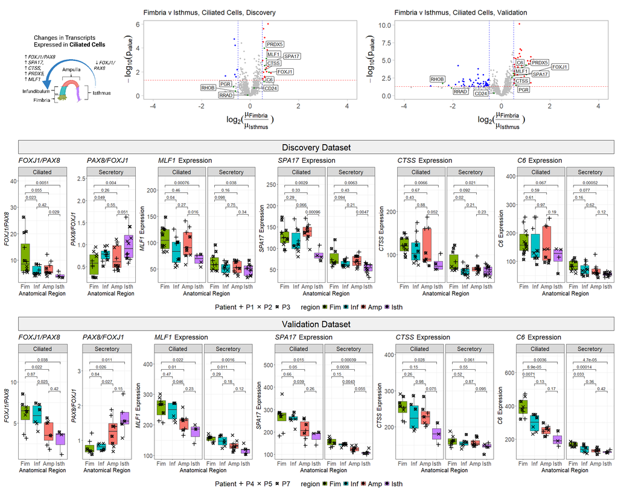

```r
library(patchwork)



# Generate Labels for adding to the graphs

top <- grid::grobTree(rectGrob(gp=gpar(fill='#F0F0F0',col= 'black')), textGrob('Discovery Dataset', gp=gpar(fontsize=25)))

bottom <- grid::grobTree(rectGrob(gp=gpar(fill='#F0F0F0',col= 'black')), textGrob('Validation Dataset', gp=gpar(fontsize=25)))



# Use patchwork to combine the final image into one complete image

wrap_elements(free(picture_3A) | fim_v_isth_disc | fim_v_isth_valid) /
  wrap_elements(top) /

 (((FvP_disc| PvF_disc ) | F3_disc[[1]] | F3_disc[[2]] |  F3_disc[[3]] | F3_disc[[4]]) +
    plot_layout(widths = c(1, 1, 2, 2, 2, 2)))/

 legend_disc /

 wrap_elements(bottom) /

 (((FvP_valid| PvF_valid) | F3_valid[[1]] | F3_valid[[2]] | F3_valid[[3]] |F3_valid[[4]]) +
    plot_layout(widths = c(1, 1, 2, 2, 2, 2)))/

 legend_valid +

 plot_layout(heights = c(5, 0.5, 4, 0.5, 0.5, 4, 0.5))
```

```r
NA
NA
NA
```